# knights-data-checks

Inigo Peng, edited by Badhia Yunes-Katz

2025-07-09

# Database Tables

## knights landing

### catch

**- Findings catch:**

- date ranges are the same
- life stage in edi data has not gone through wrangling

#### Date Range Check

*EDI `date`*

```
## [1] "2004-01-30" "2025-04-17"
```

*DB `date`*

```
## [1] "2004-01-30" "2025-04-17"
```

#### ForkLength

*EDI `forkLength`*

- 6.3 % of values in the `forkLength` column are NA.

```
##    Min. 1st Qu.  Median    Mean 3rd Qu.    Max.    NA's
##    1.00   37.00   40.00   51.82   70.00  991.00    7859
```

*DB `fork_length`*

- 6.3 % of values in the `fork_length` column are NA.

```
##    Min. 1st Qu.  Median    Mean 3rd Qu.    Max.    NA's
##    1.00   37.00   40.00   51.82   70.00  991.00    7859
```

*Forklength Exploration Plots*

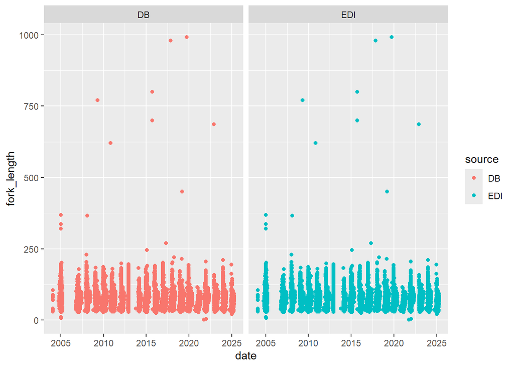

#### Run

*EDI `run`*

- 25.6 % of values in the `run` column from the EDI data are NA.

```
##
##      Fall Late fall    Spring    Winter
##     76907      1214      9742      5322
```

*DB `run`_id`*

- 0 % of values in the `run_id` column from the database are NA.

```
##
##     1     2     3     4     5
##  1214  9742 76907  5322 32009
```

#### Count

*EDI `n`*

- 0 % of values in the `n` column in edi data are NA.

```
##      Min.   1st Qu.    Median      Mean   3rd Qu.      Max.
##     0.000     1.000     1.000     2.627     1.000 15105.000
```

*DB `count`*

- 0 % of values in the `count` column in database data are NA.

```
##      Min.   1st Qu.    Median      Mean   3rd Qu.      Max.
##     0.000     1.000     1.000     2.627     1.000 15105.000
```

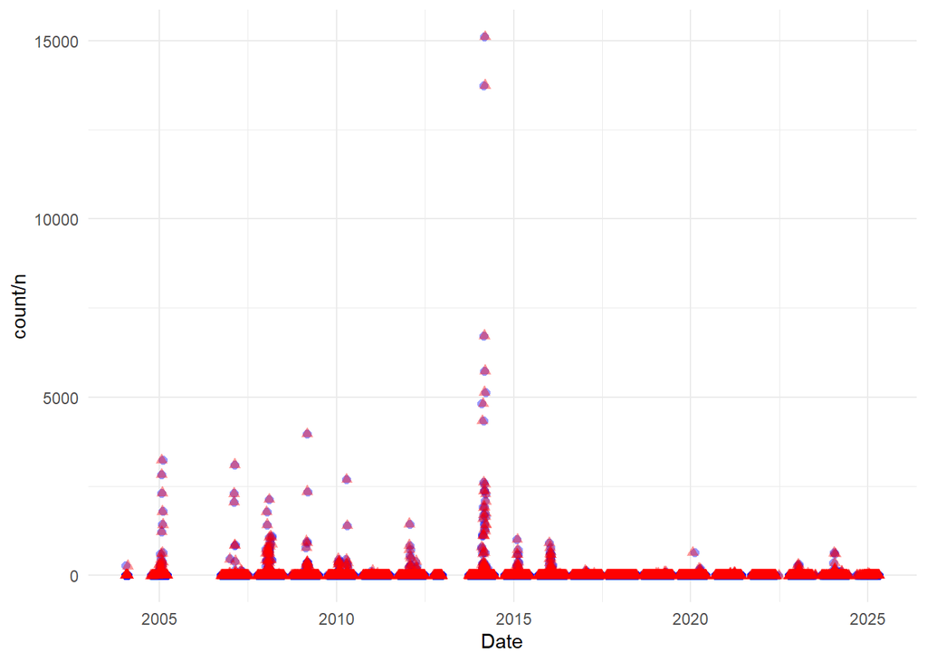

Random pick of data entry to compare between db and EDI

- test 1

```
## Rows: 1
## Columns: 17
## $ id               <int> 72644287
## $ catch_raw_id     <chr> "400"
## $ trap_location_id <int> 52
## $ date             <date> 2014-10-31
## $ count            <dbl> 1
## $ run_id           <int> 4
## $ lifestage_id     <int> 6
## $ adipose_clipped  <lgl> FALSE
## $ dead             <lgl> NA
## $ fork_length      <dbl> 66
## $ weight           <dbl> 3.2
## $ actual_count     <lgl> NA
## $ updated_at       <dttm> 2025-07-10 01:13:16
## $ stream           <chr> "sacramento river"
## $ site             <chr> "knights landing"
## $ subsite          <chr> "8.4"
## $ source           <chr> "DB"
```

```
## Rows: 1
## Columns: 22
## $ ProjectDescriptionID <dbl> 9
## $ trapVisitID          <dbl> 59
## $ visitTime            <dttm> 2014-10-31 16:15:03
## $ visitTime2           <dttm> 2014-10-31 16:15:03
## $ siteName             <chr> "knights landing"
## $ subSiteName          <chr> "8.4"
## $ visitType            <chr> "End trapping"
## $ catchRawID           <dbl> 400
## $ commonName           <chr> "Chinook salmon"
## $ releaseID            <dbl> 0
## $ run                  <chr> "Winter"
## $ fishOrigin           <chr> "Natural"
## $ lifeStage            <chr> "Silvery parr"
## $ forkLength           <dbl> 66
## $ totalLength          <dbl> NA
## $ weight               <dbl> 3.2
## $ n                    <dbl> 1
## $ trap_start_date      <dttm> 2014-10-31 08:45:03
## $ trap_end_date        <dttm> 2014-10-31 16:15:03
## $ stream               <chr> "sacramento river"
## $ date                 <date> 2014-10-31
## $ source               <chr> "EDI"
```

- test 2

```
## Rows: 1
## Columns: 17
## $ id               <int> 72577250
## $ catch_raw_id     <chr> "18663"
## $ trap_location_id <int> 51
## $ date             <date> 2012-05-11
## $ count            <dbl> 1
## $ run_id           <int> 3
## $ lifestage_id     <int> 6
## $ adipose_clipped  <lgl> FALSE
## $ dead             <lgl> NA
## $ fork_length      <dbl> 72
## $ weight           <dbl> 2.5
## $ actual_count     <lgl> NA
## $ updated_at       <dttm> 2025-07-10 01:13:16
## $ stream           <chr> "sacramento river"
## $ site             <chr> "knights landing"
## $ subsite          <chr> "8.3"
## $ source           <chr> "DB"
```

```
## Rows: 1
## Columns: 22
## $ ProjectDescriptionID <dbl> 9
## $ trapVisitID          <dbl> 959
## $ visitTime            <dttm> 2012-05-11 11:15:03
## $ visitTime2           <dttm> 2012-05-11 11:15:03
## $ siteName             <chr> "knights landing"
## $ subSiteName          <chr> "8.3"
## $ visitType            <chr> "Continue trapping"
## $ catchRawID           <dbl> 18663
## $ commonName           <chr> "Chinook salmon"
## $ releaseID            <dbl> 0
## $ run                  <chr> "Fall"
## $ fishOrigin           <chr> "Natural"
## $ lifeStage            <chr> "Silvery parr"
## $ forkLength           <dbl> 72
## $ totalLength          <dbl> NA
## $ weight               <dbl> 2.5
## $ n                    <dbl> 1
## $ trap_start_date      <dttm> 2012-05-10 10:30:03
## $ trap_end_date        <dttm> 2012-05-11 11:15:03
## $ stream               <chr> "sacramento river"
## $ date                 <date> 2012-05-11
## $ source               <chr> "EDI"
```

- test 3

```
## Rows: 1
## Columns: 17
## $ id               <int> 72574547
## $ catch_raw_id     <chr> "12000"
## $ trap_location_id <int> 51
## $ date             <date> 2012-02-01
## $ count            <dbl> 1
## $ run_id           <int> 3
## $ lifestage_id     <int> 2
## $ adipose_clipped  <lgl> FALSE
## $ dead             <lgl> NA
## $ fork_length      <dbl> 38
## $ weight           <dbl> NA
## $ actual_count     <lgl> NA
## $ updated_at       <dttm> 2025-07-10 01:13:16
## $ stream           <chr> "sacramento river"
## $ site             <chr> "knights landing"
## $ subsite          <chr> "8.3"
## $ source           <chr> "DB"
```

```
## Rows: 1
## Columns: 22
## $ ProjectDescriptionID <dbl> 9
## $ trapVisitID          <dbl> 785
## $ visitTime            <dttm> 2012-02-01 10:00:03
## $ visitTime2           <dttm> 2012-02-01 10:00:03
## $ siteName             <chr> "knights landing"
## $ subSiteName          <chr> "8.3"
## $ visitType            <chr> "Continue trapping"
## $ catchRawID           <dbl> 12000
## $ commonName           <chr> "Chinook salmon"
## $ releaseID            <dbl> 0
## $ run                  <chr> "Fall"
## $ fishOrigin           <chr> "Natural"
## $ lifeStage            <chr> "Button-up fry"
## $ forkLength           <dbl> 38
## $ totalLength          <dbl> NA
## $ weight               <dbl> NA
## $ n                    <dbl> 1
## $ trap_start_date      <dttm> 2012-01-31 10:45:03
## $ trap_end_date        <dttm> 2012-02-01 10:00:03
## $ stream               <chr> "sacramento river"
## $ date                 <date> 2012-02-01
## $ source               <chr> "EDI"
```

### trap

**- Findings:**

- date ranges are the same

#### Date Range Check

*DB `trap_visit_time_start`*

```
## [1] "2003-12-27 10:00:43 UTC" "2025-04-17 10:45:04 UTC"
```

*EDI `visitTime`*

```r
range(trap_knights_edi$visitTime)
```

```
## [1] "2003-12-27 10:00:43 UTC" "2025-04-17 10:45:04 UTC"
```

#### water_velocity

*DB `water_velocity`*

- 27.4 % of values in the `water_velocity` column are NA.

```
##     Min.  1st Qu.   Median     Mean  3rd Qu.     Max.     NA's
##    0.000    1.300    1.700    2.505    2.070 5431.000     2397
```

*EDI `waterVel`*

- 27.4 % of values in the `water_velocity` column are NA.

```
##     Min.  1st Qu.   Median     Mean  3rd Qu.     Max.     NA's
##    0.000    1.300    1.700    2.505    2.070 5431.000     2397
```

#### fishProcessed

*DB `fish_processed_id`*

- 5.2 % of values in the `fish_processed_id` column are NA.

```
##
##    2    3    4    5
## 7469  825    7    1
```

*EDI `fishProcessed`*

- 0 % of values in the `fishProcessed` column are NA.

```
##
##            N/A; not a sampling visit No catch data; fish left in live box
##                                  454                                    1
##         No catch data; fish released                  No fish were caught
##                                    7                                  825
##                       Processed fish
##                                 7469
```

Random pick of data entry by date to compare between db and EDI

- test 1

```
## Rows: 1
## Columns: 25
## $ id                         <int> 3400354
## $ trap_location_id           <int> 51
## $ trap_visit_id              <chr> "2144"
## $ visit_type_id              <int> 2
## $ trap_visit_time_start      <dttm> 2016-02-19 11:00:03
## $ trap_visit_time_end        <dttm> 2016-02-20 09:45:03
## $ trap_functioning_id        <int> NA
## $ in_half_cone_configuration <lgl> NA
## $ fish_processed_id          <int> 2
## $ rpm_start                  <dbl> 2.9
## $ rpm_end                    <dbl> 2.7
## $ total_revolutions          <dbl> 4267
## $ debris_volume              <dbl> NA
## $ debris_level_id            <int> NA
## $ discharge                  <dbl> 9920
## $ water_velocity             <dbl> 1.9
## $ water_temp                 <dbl> 54
## $ turbidity                  <dbl> 15.64
## $ include                    <lgl> NA
## $ updated_at                 <dttm> 2025-07-10 01:15:01
## $ updated_by                 <chr> "AdminJPE"
## $ stream                     <chr> "sacramento river"
## $ site                       <chr> "knights landing"
## $ subsite                    <chr> "8.3"
## $ source                     <chr> "DB"
```

```
## Rows: 1
## Columns: 26
## $ projectDescriptionID  <dbl> 9
## $ trapVisitID           <dbl> 2144
## $ visitTime             <dttm> 2016-02-20 09:45:03
## $ visitTime2            <dttm> 2016-02-20 09:45:03
## $ siteName              <chr> "knights landing"
## $ subSiteName           <chr> "8.3"
## $ visitType             <chr> "Continue trapping"
## $ fishProcessed         <chr> "Processed fish"
## $ trapFunctioning       <chr> "Trap functioning normally"
## $ counterAtStart        <dbl> NA
## $ counterAtEnd          <dbl> 4267
## $ rpmRevolutionsAtStart <dbl> 2.9
## $ rpmRevolutionsAtEnd   <dbl> 2.7
## $ includeCatch          <chr> "Yes"
## $ discharge             <dbl> 9920
## $ waterVel              <dbl> 1.9
## $ waterTemp             <dbl> 54
## $ lightPenetration      <dbl> 20
## $ turbidity             <dbl> 15.64
## $ dissolvedOxygen       <dbl> NA
## $ conductivity          <dbl> NA
## $ trap_start_date       <dttm> 2016-02-19 11:00:03
## $ trap_end_date         <dttm> 2016-02-20 09:45:03
## $ stream                <chr> "sacramento river"
## $ date                  <date> 2016-02-20
## $ source                <chr> "EDI"
```

- test 2

```
## Rows: 1
## Columns: 25
## $ id                         <int> 3401509
## $ trap_location_id           <int> 51
## $ trap_visit_id              <chr> "6083"
## $ visit_type_id              <int> 2
## $ trap_visit_time_start      <dttm> 2020-02-05 10:15:13
## $ trap_visit_time_end        <dttm> 2020-02-06 10:45:44
## $ trap_functioning_id        <int> NA
## $ in_half_cone_configuration <lgl> NA
## $ fish_processed_id          <int> 2
## $ rpm_start                  <dbl> 1.6
## $ rpm_end                    <dbl> 1.7
## $ total_revolutions          <dbl> 2796
## $ debris_volume              <dbl> NA
## $ debris_level_id            <int> NA
## $ discharge                  <dbl> 8503
## $ water_velocity             <dbl> 2.1
## $ water_temp                 <dbl> 47.8
## $ turbidity                  <dbl> 10.92
## $ include                    <lgl> NA
## $ updated_at                 <dttm> 2025-07-10 01:15:01
## $ updated_by                 <chr> "AdminJPE"
## $ stream                     <chr> "sacramento river"
## $ site                       <chr> "knights landing"
## $ subsite                    <chr> "8.3"
## $ source                     <chr> "DB"
```

```
## Rows: 1
## Columns: 26
## $ projectDescriptionID  <dbl> 9
## $ trapVisitID           <dbl> 6083
## $ visitTime             <dttm> 2020-02-06 10:45:44
## $ visitTime2            <dttm> 2020-02-06 10:45:44
## $ siteName              <chr> "knights landing"
## $ subSiteName           <chr> "8.3"
## $ visitType             <chr> "Continue trapping"
## $ fishProcessed         <chr> "Processed fish"
## $ trapFunctioning       <chr> "Trap functioning normally"
## $ counterAtStart        <dbl> NA
## $ counterAtEnd          <dbl> 2796
## $ rpmRevolutionsAtStart <dbl> 1.6
## $ rpmRevolutionsAtEnd   <dbl> 1.7
## $ includeCatch          <chr> "Yes"
## $ discharge             <dbl> 8503
## $ waterVel              <dbl> 2.1
## $ waterTemp             <dbl> 47.8
## $ lightPenetration      <dbl> 26
## $ turbidity             <dbl> 10.92
## $ dissolvedOxygen       <dbl> 100.6
## $ conductivity          <dbl> 244.6
## $ trap_start_date       <dttm> 2020-02-05 10:15:13
## $ trap_end_date         <dttm> 2020-02-06 10:45:44
## $ stream                <chr> "sacramento river"
## $ date                  <date> 2020-02-06
## $ source                <chr> "EDI"
```

- test 3

```
## Rows: 1
## Columns: 25
## $ id                         <int> 3401633
## $ trap_location_id           <int> 51
## $ trap_visit_id              <chr> "6344"
## $ visit_type_id              <int> 4
## $ trap_visit_time_start      <dttm> 2020-09-25 11:15:16
## $ trap_visit_time_end        <dttm> 2020-09-25 11:15:16
## $ trap_functioning_id        <int> NA
## $ in_half_cone_configuration <lgl> NA
## $ fish_processed_id          <int> NA
## $ rpm_start                  <dbl> NA
## $ rpm_end                    <dbl> 1.5
## $ total_revolutions          <dbl> NA
## $ debris_volume              <dbl> NA
## $ debris_level_id            <int> NA
## $ discharge                  <dbl> 6041
## $ water_velocity             <dbl> 1.7
## $ water_temp                 <dbl> 65.8
## $ turbidity                  <dbl> 3.52
## $ include                    <lgl> NA
## $ updated_at                 <dttm> 2025-07-10 01:15:01
## $ updated_by                 <chr> "AdminJPE"
## $ stream                     <chr> "sacramento river"
## $ site                       <chr> "knights landing"
## $ subsite                    <chr> "8.3"
## $ source                     <chr> "DB"
```

```
## Rows: 1
## Columns: 26
## $ projectDescriptionID  <dbl> 9
## $ trapVisitID           <dbl> 6344
## $ visitTime             <dttm> 2020-09-25 11:15:16
## $ visitTime2            <dttm> 2020-09-25 11:15:16
## $ siteName              <chr> "knights landing"
## $ subSiteName           <chr> "8.3"
## $ visitType             <chr> "Start trap & begin trapping"
## $ fishProcessed         <chr> "N/A; not a sampling visit"
## $ trapFunctioning       <chr> "Trap functioning normally"
## $ counterAtStart        <dbl> NA
## $ counterAtEnd          <dbl> NA
## $ rpmRevolutionsAtStart <dbl> NA
## $ rpmRevolutionsAtEnd   <dbl> 1.5
## $ includeCatch          <chr> "Yes"
## $ discharge             <dbl> 6041
## $ waterVel              <dbl> 1.7
## $ waterTemp             <dbl> 65.8
## $ lightPenetration      <dbl> 42
## $ turbidity             <dbl> 3.52
## $ dissolvedOxygen       <dbl> 100.6
## $ conductivity          <dbl> 151.9
## $ trap_start_date       <dttm> 2020-09-25 11:15:16
## $ trap_end_date         <dttm> 2020-09-25 11:15:16
## $ stream                <chr> "sacramento river"
## $ date                  <date> 2020-09-25
## $ source                <chr> "EDI"
```

- test 4

```
## Rows: 1
## Columns: 25
## $ id                         <int> 3404852
## $ trap_location_id           <int> 52
## $ trap_visit_id              <chr> "2382"
## $ visit_type_id              <int> 2
## $ trap_visit_time_start      <dttm> 2016-09-05 09:15:03
## $ trap_visit_time_end        <dttm> 2016-09-06 09:15:03
## $ trap_functioning_id        <int> NA
## $ in_half_cone_configuration <lgl> NA
## $ fish_processed_id          <int> 2
## $ rpm_start                  <dbl> 2
## $ rpm_end                    <dbl> 2.2
## $ total_revolutions          <dbl> 2760
## $ debris_volume              <dbl> NA
## $ debris_level_id            <int> NA
## $ discharge                  <dbl> 8030
## $ water_velocity             <dbl> 1.5
## $ water_temp                 <dbl> 68
## $ turbidity                  <dbl> 14.31
## $ include                    <lgl> NA
## $ updated_at                 <dttm> 2025-07-10 01:15:01
## $ updated_by                 <chr> "AdminJPE"
## $ stream                     <chr> "sacramento river"
## $ site                       <chr> "knights landing"
## $ subsite                    <chr> "8.4"
## $ source                     <chr> "DB"
```

```
## Rows: 1
## Columns: 26
## $ projectDescriptionID  <dbl> 9
## $ trapVisitID           <dbl> 2382
## $ visitTime             <dttm> 2016-09-06 09:15:03
## $ visitTime2            <dttm> 2016-09-06 09:15:03
## $ siteName              <chr> "knights landing"
## $ subSiteName           <chr> "8.4"
## $ visitType             <chr> "Continue trapping"
## $ fishProcessed         <chr> "Processed fish"
## $ trapFunctioning       <chr> "Trap functioning normally"
## $ counterAtStart        <dbl> NA
## $ counterAtEnd          <dbl> 2760
## $ rpmRevolutionsAtStart <dbl> 2
## $ rpmRevolutionsAtEnd   <dbl> 2.2
## $ includeCatch          <chr> "Yes"
## $ discharge             <dbl> 8030
## $ waterVel              <dbl> 1.5
## $ waterTemp             <dbl> 68
## $ lightPenetration      <dbl> 24.5
## $ turbidity             <dbl> 14.31
## $ dissolvedOxygen       <dbl> NA
## $ conductivity          <dbl> NA
## $ trap_start_date       <dttm> 2016-09-05 09:15:03
## $ trap_end_date         <dttm> 2016-09-06 09:15:03
## $ stream                <chr> "sacramento river"
## $ date                  <date> 2016-09-06
## $ source                <chr> "EDI"
```

### recapture

**- Findings:**

- date ranges are the same

#### Date Range Check

*DB `date`*

```
## [1] "2007-01-02" "2023-04-27"
```

*EDI `date`*

```r
range(recapture_knights_edi$date)
```

```
## [1] "2007-01-02" "2023-04-27"
```

#### Count

*DB `count`*

- 0 % of values in the `count` column are NA.

```
##    Min. 1st Qu.  Median    Mean 3rd Qu.    Max.
##   1.000   1.000   1.000   1.012   1.000   4.000
```

*EDI `n`*

- 0 % of values in the `n` column are NA.

```r
summary(recapture_knights_edi$n)
```

```
##    Min. 1st Qu.  Median    Mean 3rd Qu.    Max.
##   1.000   1.000   1.000   1.012   1.000   4.000
```

#### Run

*EDI `run`*

- 1.5 % of values in the `run` column are NA.

[output not shown]

*DB `run`_id`*

- 0 % of values in the `run_id` column are NA.

```
##
##   1   2   3   4   5
##   5   9 305   2   5
```

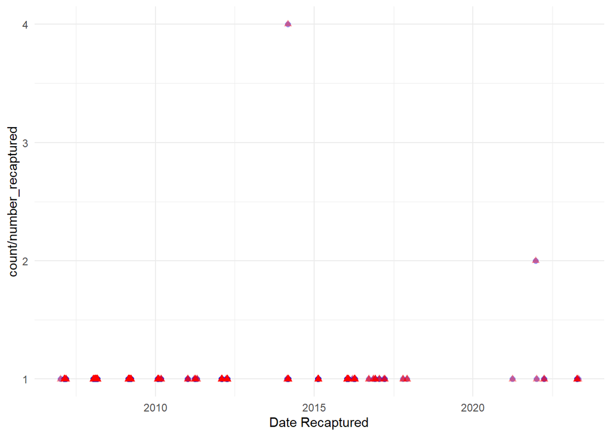

#### forkLength

*EDI `forkLength`*

- 1.5 % of values in the `forkLength` column are NA.

*DB `fork_length`*

- 1.5 % of values in the `fork_length` column are NA.

Random pick of data entry to compare between db and EDI

- test 1

```
## Rows: 1
## Columns: 17
## $ id               <int> 376512
## $ trap_location_id <int> 52
## $ catch_raw_id     <int> 16477
## $ date             <date> 2012-04-03
## $ count            <dbl> 1
## $ run_id           <int> 3
## $ lifestage_id     <int> 5
## $ adipose_clipped  <lgl> FALSE
## $ dead             <lgl> NA
## $ fork_length      <dbl> 47
## $ weight           <dbl> NA
## $ release_id       <chr> "266"
## $ updated_at       <dttm> 2025-07-10 01:14:59
## $ stream           <chr> "sacramento river"
## $ site             <chr> "knights landing"
## $ subsite          <chr> "8.4"
## $ source           <chr> "DB"
```

```
## Rows: 1
## Columns: 24
## $ ProjectDescriptionID <dbl> 9
## $ catchRawID           <dbl> 16477
## $ trapVisitID          <dbl> 896
## $ commonName           <chr> "Chinook salmon"
## $ releaseID            <dbl> 266
## $ run                  <chr> "Fall"
## $ fishOrigin           <chr> "Natural"
## $ lifeStage            <chr> "Parr"
## $ forkLength           <dbl> 47
## $ n                    <dbl> 1
## $ visitTime            <dttm> 2012-04-03 11:00:03
## $ visitTime2           <dttm> 2012-04-03 11:00:03
## $ visitType            <chr> "Continue trapping"
## $ siteName             <chr> "knights landing"
## $ subSiteName          <chr> "8.4"
## $ markType             <chr> "Pigment / dye"
## $ markColor            <chr> "Brown"
## $ markPosition         <chr> "Whole body"
## $ markCode             <lgl> NA
## $ trap_start_date      <dttm> 2012-04-02 12:30:03
## $ trap_end_date        <dttm> 2012-04-03 11:00:03
## $ stream               <chr> "sacramento river"
## $ date                 <date> 2012-04-03
## $ source               <chr> "EDI"
```

- test 2

```
## Rows: 1
## Columns: 17
## $ id               <int> 376691
## $ trap_location_id <int> 52
## $ catch_raw_id     <int> 95309
## $ date             <date> 2008-02-05
## $ count            <dbl> 1
## $ run_id           <int> 3
## $ lifestage_id     <int> 5
## $ adipose_clipped  <lgl> FALSE
## $ dead             <lgl> NA
## $ fork_length      <dbl> 49
## $ weight           <dbl> NA
## $ release_id       <chr> "560"
## $ updated_at       <dttm> 2025-07-10 01:14:59
## $ stream           <chr> "sacramento river"
## $ site             <chr> "knights landing"
## $ subsite          <chr> "8.4"
## $ source           <chr> "DB"
```

```
## Rows: 1
## Columns: 24
## $ ProjectDescriptionID <dbl> 9
## $ catchRawID           <dbl> 95309
## $ trapVisitID          <dbl> 4028
## $ commonName           <chr> "Chinook salmon"
## $ releaseID            <dbl> 560
## $ run                  <chr> "Fall"
## $ fishOrigin           <chr> "Natural"
## $ lifeStage            <chr> "Parr"
## $ forkLength           <dbl> 49
## $ n                    <dbl> 1
## $ visitTime            <dttm> 2008-02-05 12:30:00
## $ visitTime2           <dttm> 2008-02-05 12:30:00
## $ visitType            <chr> "Unplanned restart"
## $ siteName             <chr> "knights landing"
## $ subSiteName          <chr> "8.4"
## $ markType             <chr> "Pigment / dye"
## $ markColor            <chr> "Brown"
## $ markPosition         <chr> "Whole body"
## $ markCode             <lgl> NA
## $ trap_start_date      <dttm> 2008-02-04 12:15:00
## $ trap_end_date        <dttm> 2008-02-05 12:30:00
## $ stream               <chr> "sacramento river"
## $ date                 <date> 2008-02-05
## $ source               <chr> "EDI"
```

- test 3

```
## Rows: 1
## Columns: 17
## $ id               <int> 376747
## $ trap_location_id <int> 52
## $ catch_raw_id     <int> 105858
## $ date             <date> 2007-02-15
## $ count            <dbl> 1
## $ run_id           <int> 3
## $ lifestage_id     <int> 5
## $ adipose_clipped  <lgl> FALSE
## $ dead             <lgl> NA
## $ fork_length      <dbl> 38
## $ weight           <dbl> NA
## $ release_id       <chr> "556"
## $ updated_at       <dttm> 2025-07-10 01:14:59
## $ stream           <chr> "sacramento river"
## $ site             <chr> "knights landing"
## $ subsite          <chr> "8.4"
## $ source           <chr> "DB"
```

```
## Rows: 1
## Columns: 24
## $ ProjectDescriptionID <dbl> 9
## $ catchRawID           <dbl> 105858
## $ trapVisitID          <dbl> 4386
## $ commonName           <chr> "Chinook salmon"
## $ releaseID            <dbl> 556
## $ run                  <chr> "Fall"
## $ fishOrigin           <chr> "Natural"
## $ lifeStage            <chr> "Parr"
## $ forkLength           <dbl> 38
## $ n                    <dbl> 1
## $ visitTime            <dttm> 2007-02-15 11:00:00
## $ visitTime2           <dttm> 2007-02-15 11:00:00
## $ visitType            <chr> "Continue trapping"
## $ siteName             <chr> "knights landing"
## $ subSiteName          <chr> "8.4"
## $ markType             <chr> "Pigment / dye"
## $ markColor            <chr> "Brown"
## $ markPosition         <chr> "Whole body"
## $ markCode             <lgl> NA
## $ trap_start_date      <dttm> 2007-02-14 11:15:00
## $ trap_end_date        <dttm> 2007-02-15 11:00:00
## $ stream               <chr> "sacramento river"
## $ date                 <date> 2007-02-15
## $ source               <chr> "EDI"
```

- test 4

```
## Rows: 1
## Columns: 17
## $ id               <int> 376720
## $ trap_location_id <int> 51
## $ catch_raw_id     <int> 99819
## $ date             <date> 2008-03-02
## $ count            <dbl> 1
## $ run_id           <int> 3
## $ lifestage_id     <int> 5
## $ adipose_clipped  <lgl> FALSE
## $ dead             <lgl> NA
## $ fork_length      <dbl> 39
## $ weight           <dbl> NA
## $ release_id       <chr> "564"
## $ updated_at       <dttm> 2025-07-10 01:14:59
## $ stream           <chr> "sacramento river"
## $ site             <chr> "knights landing"
## $ subsite          <chr> "8.3"
## $ source           <chr> "DB"
```

```
## Rows: 1
## Columns: 24
## $ ProjectDescriptionID <dbl> 9
## $ catchRawID           <dbl> 99819
## $ trapVisitID          <dbl> 4079
## $ commonName           <chr> "Chinook salmon"
## $ releaseID            <dbl> 564
## $ run                  <chr> "Fall"
## $ fishOrigin           <chr> "Natural"
## $ lifeStage            <chr> "Parr"
## $ forkLength           <dbl> 39
## $ n                    <dbl> 1
## $ visitTime            <dttm> 2008-03-02 10:00:00
## $ visitTime2           <dttm> 2008-03-02 10:00:00
## $ visitType            <chr> "Continue trapping"
## $ siteName             <chr> "knights landing"
## $ subSiteName          <chr> "8.3"
## $ markType             <chr> "Pigment / dye"
## $ markColor            <chr> "Brown"
## $ markPosition         <chr> "Whole body"
## $ markCode             <lgl> NA
## $ trap_start_date      <dttm> 2008-03-01 10:00:00
## $ trap_end_date        <dttm> 2008-03-02 10:00:00
## $ stream               <chr> "sacramento river"
## $ date                 <date> 2008-03-02
## $ source               <chr> "EDI"
```

### release

**- Findings:**

- date ranges are the same

#### Date Range Check

*DB `date_released`*

```
## [1] "2006-12-18 13:15:50 UTC" "2025-02-12 12:30:50 UTC"
```

*EDI `releaseTime`*

```r
range(release_knights_edi$releaseTime)
```

```
## [1] "2006-12-18 13:15:50 UTC" "2025-02-12 12:30:50 UTC"
```

#### markedLifeStage

*EDI `markedLifeStage`*

- 76.1 % of values in the `markedLifeStage` column are NA.

```
##
## Juvenile    Smolt
##       19        3
```

*DB `lifestage_id`*

- 0 % of values in the `fork_length` column are NA.

```
##
##  1  7 11
##  3 70 19
```

#### nReleased

*EDI `nReleased`*

- 0 % of values in the `nReleased` column are NA.

```
##    Min. 1st Qu.  Median    Mean 3rd Qu.    Max.
##    81.0   290.8   537.0   900.6  1106.0  7180.0
```

*DB `number_released`*

- 0 % of values in the `number_released` column are NA.

```
##    Min. 1st Qu.  Median    Mean 3rd Qu.    Max.
##    81.0   290.8   537.0   900.6  1106.0  7180.0
```

*Exploration Plots*

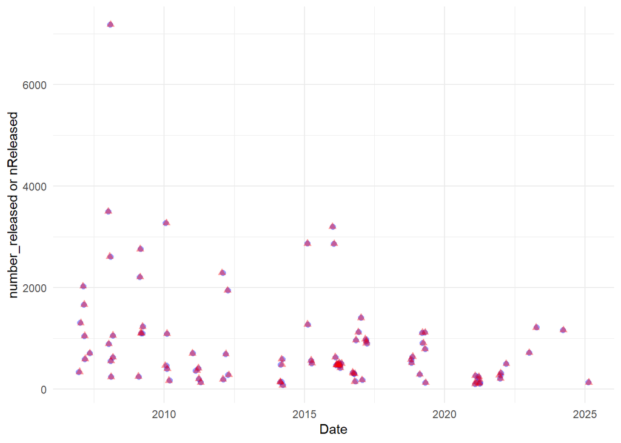

Random pick of data entry by date to compare between db and EDI

- test 1

```
## Rows: 1
## Columns: 15
## $ id                          <int> 129400
## $ trap_location_id            <int> 54
## $ release_id                  <chr> "267"
## $ date_released               <dttm> 2012-03-19 16:00:17
## $ run_id                      <int> NA
## $ median_fork_length_released <dbl> NA
## $ lifestage_id                <int> 7
## $ origin_id                   <int> 4
## $ number_released             <dbl> 696
## $ updated_at                  <dttm> 2025-07-10 01:15:00
## $ updated_by                  <chr> "AdminJPE"
## $ stream                      <chr> "sacramento river"
## $ site                        <chr> "knights landing"
## $ subsite                     <chr> NA
## $ source                      <chr> "DB"
```

```
## Rows: 1
## Columns: 19
## $ projectDescriptionID <dbl> 9
## $ releaseID            <dbl> 267
## $ releaseTime          <dttm> 2012-03-19 16:00:17
## $ commonName           <chr> "Chinook salmon"
## $ markedRun            <chr> "Other"
## $ markedLifeStage      <chr> NA
## $ markedFishOrigin     <chr> "Unknown"
## $ sourceOfFishSite     <chr> "Knights Landing RST"
## $ releaseSite          <chr> "knights landing release site"
## $ releaseSubSite       <chr> NA
## $ nReleased            <dbl> 696
## $ testDays             <dbl> 10
## $ appliedMarkType      <chr> "Pigment / dye"
## $ appliedMarkColor     <chr> "Brown"
## $ appliedMarkPosition  <chr> "Whole body"
## $ IncludeInAnalysis    <chr> "Yes"
## $ stream               <chr> "sacramento river"
## $ date                 <date> 2012-03-19
## $ source               <chr> "EDI"
```

- test 2

```
## Rows: 1
## Columns: 15
## $ id                          <int> 129466
## $ trap_location_id            <int> 54
## $ release_id                  <chr> "275"
## $ date_released               <dttm> 2016-02-24 11:15:17
## $ run_id                      <int> 3
## $ median_fork_length_released <dbl> NA
## $ lifestage_id                <int> 7
## $ origin_id                   <int> 2
## $ number_released             <dbl> 489
## $ updated_at                  <dttm> 2025-07-10 01:15:00
## $ updated_by                  <chr> "AdminJPE"
## $ stream                      <chr> "sacramento river"
## $ site                        <chr> "knights landing"
## $ subsite                     <chr> NA
## $ source                      <chr> "DB"
```

```
## Rows: 1
## Columns: 19
## $ projectDescriptionID <dbl> 9
## $ releaseID            <dbl> 275
## $ releaseTime          <dttm> 2016-02-24 11:15:17
## $ commonName           <chr> "Chinook salmon"
## $ markedRun            <chr> "Fall"
## $ markedLifeStage      <chr> NA
## $ markedFishOrigin     <chr> "Hatchery"
## $ sourceOfFishSite     <chr> "Not yet assigned"
## $ releaseSite          <chr> "knights landing release site"
## $ releaseSubSite       <chr> NA
## $ nReleased            <dbl> 489
## $ testDays             <dbl> 28
## $ appliedMarkType      <chr> "Elastomer"
## $ appliedMarkColor     <chr> "Orange"
## $ appliedMarkPosition  <chr> "Nose"
## $ IncludeInAnalysis    <chr> "Yes"
## $ stream               <chr> "sacramento river"
## $ date                 <date> 2016-02-24
## $ source               <chr> "EDI"
```

- test 3

```
## Rows: 1
## Columns: 15
## $ id                          <int> 129397
## $ trap_location_id            <int> 54
## $ release_id                  <chr> "264"
## $ date_released               <dttm> 2014-03-19 08:30:17
## $ run_id                      <int> 6
## $ median_fork_length_released <dbl> NA
## $ lifestage_id                <int> 7
## $ origin_id                   <int> 4
## $ number_released             <dbl> 81
## $ updated_at                  <dttm> 2025-07-10 01:15:00
## $ updated_by                  <chr> "AdminJPE"
## $ stream                      <chr> "sacramento river"
## $ site                        <chr> "knights landing"
## $ subsite                     <chr> NA
## $ source                      <chr> "DB"
```

```
## Rows: 1
## Columns: 19
## $ projectDescriptionID <dbl> 9
## $ releaseID            <dbl> 264
## $ releaseTime          <dttm> 2014-03-19 08:30:17
## $ commonName           <chr> "Chinook salmon"
## $ markedRun            <chr> "Not recorded"
## $ markedLifeStage      <chr> NA
## $ markedFishOrigin     <chr> "Unknown"
## $ sourceOfFishSite     <chr> "Knights Landing RST"
## $ releaseSite          <chr> "knights landing release site"
## $ releaseSubSite       <chr> NA
## $ nReleased            <dbl> 81
## $ testDays             <dbl> 7
## $ appliedMarkType      <chr> "Pigment / dye"
## $ appliedMarkColor     <chr> "Brown"
## $ appliedMarkPosition  <chr> "Whole body"
## $ IncludeInAnalysis    <chr> "Yes"
## $ stream               <chr> "sacramento river"
## $ date                 <date> 2014-03-19
## $ source               <chr> "EDI"
```

- test 4

```
## Rows: 1
## Columns: 15
## $ id                          <int> 129451
## $ trap_location_id            <int> 54
## $ release_id                  <chr> "612"
## $ date_released               <dttm> 2023-01-10 10:30:50
## $ run_id                      <int> 3
## $ median_fork_length_released <dbl> NA
## $ lifestage_id                <int> 11
## $ origin_id                   <int> 1
## $ number_released             <dbl> 721
## $ updated_at                  <dttm> 2025-07-10 01:15:00
## $ updated_by                  <chr> "AdminJPE"
## $ stream                      <chr> "sacramento river"
## $ site                        <chr> "knights landing"
## $ subsite                     <chr> NA
## $ source                      <chr> "DB"
```

```
## Rows: 1
## Columns: 19
## $ projectDescriptionID <dbl> 9
## $ releaseID            <dbl> 612
## $ releaseTime          <dttm> 2023-01-10 10:30:50
## $ commonName           <chr> "Chinook salmon"
## $ markedRun            <chr> "Fall"
## $ markedLifeStage      <chr> "Juvenile"
## $ markedFishOrigin     <chr> "Natural"
## $ sourceOfFishSite     <chr> "Knights Landing RST"
## $ releaseSite          <chr> "knights landing release site"
## $ releaseSubSite       <chr> NA
## $ nReleased            <dbl> 721
## $ testDays             <dbl> 28
## $ appliedMarkType      <chr> "Pigment / dye"
## $ appliedMarkColor     <chr> "Brown"
## $ appliedMarkPosition  <chr> "Whole body"
## $ IncludeInAnalysis    <chr> "Yes"
## $ stream               <chr> "sacramento river"
## $ date                 <date> 2023-01-10
## $ source               <chr> "EDI"
```

### releasefish

**- Findings:**

#### column names

*EDI*

```
##  [1] "projectDescriptionID"        "releaseFishID"
##  [3] "releaseID"                   "forkLength"
##  [5] "id"                          "trap_location_id"
##  [7] "date_released"               "run_id"
##  [9] "median_fork_length_released" "lifestage_id"
## [11] "origin_id"                   "number_released"
## [13] "updated_at"                  "updated_by"
```

*DB*

```
## [1] "id"               "trap_location_id" "release_id"       "fork_length"
## [5] "updated_at"       "release_fish_id"  "stream"           "site"
## [9] "subsite"
```

#### forkLength

*EDI `forkLength`*

- 4.7 % of values in the `forkLength` column are NA.

```
##    Min. 1st Qu.  Median    Mean 3rd Qu.    Max.    NA's
##   41.00   54.00   61.00   78.74  104.00  191.00     117
```

*DB `fork_length`*

- 4.7 % of values in the `fork_length` column are NA.

```
##    Min. 1st Qu.  Median    Mean 3rd Qu.    Max.    NA's
##   41.00   54.00   61.00   78.74  104.00  191.00     117
```